# Confident gene-set construction for nuclear RNA-seq counting

BRC

2026-08-21

# Purpose

We count our nuclear libraries over whole gene bodies from the BRC current annotation. That GENCODE annotation came from the UCSC Table Browser and is just gene models: coordinates, but no biotype, no symbol, and nothing to say whether a gene is still current. This report adds that information in R and builds a per-gene confidence table we can filter on before differential expression. It is one knitted document, so it is also the record of how the gene set was made.

We use two sources. The gene models come from the annotation itself (`rtracklayer::import`); from them we take the gene-body intervals we count over, plus a few signals that need nothing external (whether a gene has a complete ORF, how many exons and transcripts it has). Everything the annotation lacks — biotype, symbol, current-or-retired status, and the confidence attributes CCDS, TSL, APPRIS and GENCODE-basic — comes from a pinned Ensembl release through biomaRt. Pinning the release keeps the retired call reproducible.

# 1. Import the GTF (once) and restrict to counted sequences

```r
gtf_cache <- file.path(params$cache_dir, "gtf_import.rds")
if (file.exists(gtf_cache)) {
  gtf <- readRDS(gtf_cache)
} else {
  gtf <- rtracklayer::import(params$gtf)
  saveRDS(gtf, gtf_cache)
}
if (length(params$keep_seqnames) > 0)
  gtf <- gtf[as.character(seqnames(gtf)) %in% params$keep_seqnames]
gtf$type <- as.character(gtf$type)
cat(sprintf("Features: %d over %d sequences\n", length(gtf),
            length(unique(as.character(seqnames(gtf))))))
```

```
## Features: 2491508 over 25 sequences
```

# 2. Gene bodies + intrinsic confidence signals (from the GTF, in R)

A gene body is the locus extent: the smallest start and largest end across the gene’s features. That is the interval `genes(txdb)` gives `featureCounts`, so these flags describe what we actually count. From the same models we take a few signals that need nothing external:

- `complete_orf` — the gene has a transcript with both a start and a stop codon, i.e. a complete CDS model rather than a fragment.
- `is_coding` — any CDS is annotated.
- `multi_exon` — some transcript has more than one exon. Single-exon-only loci are enriched for processed pseudogenes and retrogenes, and they matter here because a single-exon locus has no introns for the nuclear reads to fall in.
- `n_tx`, `max_exons` — isoform and exon structure, kept for context.

```r
md <- as.data.frame(mcols(gtf))
md$seqnames <- as.character(seqnames(gtf))
md$start_ <- start(gtf); md$end_ <- end(gtf); md$strand_ <- as.character(strand(gtf))

# gene-body extent over ALL features of the gene (robust to missing transcript rows)
bodies <- md %>% filter(!is.na(gene_id)) %>%
  group_by(gene_id) %>%
  summarise(chr = dplyr::first(seqnames), strand = dplyr::first(strand_),
            start = min(start_), end = max(end_), .groups = "drop") %>%
  mutate(width = end - start + 1)

# transcript-level structure -> gene rollup
tx <- md %>% filter(!is.na(transcript_id)) %>%
  group_by(gene_id, transcript_id) %>%
  summarise(n_exon    = sum(type == "exon"),
            has_start = any(type == "start_codon"),
            has_stop  = any(type == "stop_codon"),
            has_cds   = any(type == "CDS"),
            .groups = "drop")
intrinsic <- tx %>% group_by(gene_id) %>%
  summarise(n_tx = dplyr::n_distinct(transcript_id),
            max_exons = max(n_exon),
            multi_exon = any(n_exon > 1),
            complete_orf = any(has_start & has_stop),
            is_coding = any(has_cds),
            .groups = "drop")

gene_tbl <- left_join(bodies, intrinsic, by = "gene_id")
n0 <- nrow(gene_tbl)
cat(sprintf("Gene bodies: %d\n", n0))
```

```
## Gene bodies: 60107
```

# 3. Pinned Ensembl annotation + confidence attributes (biomaRt)

This step fills in everything the annotation lacks. We query biomaRt filtered to our gene IDs, in chunks with a few retries each, because one genome-wide pull usually has its connection reset partway through. Gene-level and transcript-level attributes go in separate queries, otherwise biomaRt throws its “attributes belong to different pages” error. The connection tries the pinned archive first (that is what makes a run reproducible) and falls back to a live mirror of the current release if the archive is down. If Ensembl cannot be reached at all we drop to a local NCBI annotation (`org.Hs.eg.db`) so the report still builds; the Ensembl-only attributes (CCDS, TSL, APPRIS, GENCODE-basic) are then missing and an Entrez cross-reference stands in for coding support. The source used is printed below, and the result is cached per release so re-knitting stays offline.

The terms this section brings in, since they drive the tier later:

| Term | What it means |
| --- | --- |
| **gene_biotype** | Ensembl’s classification of a gene — `protein_coding`, `lncRNA`, various pseudogene classes, small-RNA classes, etc. We keep only the biotypes we care about. |
| **retired** | The gene’s Ensembl ID is no longer present in the pinned release, i.e. it has been withdrawn or merged since the annotation was built. Measured against Ensembl itself, not NCBI. |
| **CCDS** (`has_ccds`) | The gene has a transcript in the Consensus CDS set — a coding region that Ensembl, NCBI and UCSC independently agree on. A strong “this is a real coding gene” mark. |
| **TSL** (`min_tsl`) | Transcript Support Level, Ensembl’s 1–5 rating of how well a transcript model is backed by mRNA/EST evidence (1 = best). We take the best level over a gene’s transcripts. |
| **APPRIS principal** (`has_appris_principal`) | The gene has an APPRIS-nominated principal isoform — the transcript APPRIS considers the main functional one, a sign of a well-characterised coding gene. |
| **GENCODE basic** (`has_gencode_basic`) | The gene has a transcript in the GENCODE “basic” set — a representative, well-supported subset. Nearly every gene has one, so it is weak on its own. |
| **HGNC-approved symbol** (`approved_symbol`) | The gene has a curated HGNC identifier / a real symbol, as opposed to a clone-based placeholder like `AC0…` or `RP11-` that flags an uncharacterised locus. |
| **Entrez cross-reference** (`has_entrez`) | The gene maps to a current NCBI (Entrez) gene — a second, independent authority agreeing the locus is real. Used as the coding-support stand-in when working offline. |

```r
bm_cache <- file.path(params$cache_dir, sprintf("annotation_%s.rds", params$ensembl_version))

# --- connect: PINNED archive first (reproducible), else current release via a live mirror ---
connect_mart <- function(version) {
  if (is.numeric(version) || grepl("^[0-9]+$", version)) {
    m <- tryCatch(biomaRt::useEnsembl("genes", "hsapiens_gene_ensembl",
                                      version = as.integer(version)), error = function(e) NULL)
    if (!is.null(m)) return(list(mart = m, used = paste0("release ", version, " (pinned archive)")))
    message("Pinned archive for release ", version, " unreachable; trying current release.")
  }
  for (mir in list(NULL, "useast", "asia", "www")) {
    m <- tryCatch(
      if (is.null(mir)) biomaRt::useEnsembl("genes", "hsapiens_gene_ensembl")
      else biomaRt::useEnsembl("genes", "hsapiens_gene_ensembl", mirror = mir),
      error = function(e) NULL)
    if (!is.null(m)) return(list(mart = m,
      used = paste0("current release", if (!is.null(mir)) paste0(" (mirror: ", mir, ")") else ""))
    )
  }
  stop("Could not connect to Ensembl biomaRt on any host.")
}

# --- resilient fetch: FILTERED, CHUNKED, with per-chunk retries ---
getBM_chunked <- function(attrs, ids, mart, chunk = 1200, tries = 3) {
  out <- list()
  for (i in seq(1, length(ids), by = chunk)) {
    v <- ids[i:min(i + chunk - 1, length(ids))]; r <- NULL
    for (t in seq_len(tries)) {
      r <- tryCatch(biomaRt::getBM(attrs, filters = "ensembl_gene_id", values = v, mart = mart),
                    error = function(e) NULL)
      if (!is.null(r)) break
    }
    if (is.null(r)) stop("getBM failed for a chunk after ", tries, " tries")
    out[[length(out) + 1]] <- r
  }
  dplyr::bind_rows(out)
}

fetch_biomart <- function(ids, version) {
  conn <- connect_mart(version); mart <- conn$mart
  pick <- function(x) intersect(x, biomaRt::listAttributes(mart)$name)
  g  <- getBM_chunked(pick(c("ensembl_gene_id","external_gene_name","hgnc_symbol",
                             "hgnc_id","gene_biotype","entrezgene_id")), ids, mart)
  tx <- getBM_chunked(pick(c("ensembl_gene_id","ensembl_transcript_id","transcript_tsl",
                             "transcript_appris","ccds","transcript_gencode_basic")), ids, mart)
  list(gene = g, tx = tx, mode = "biomaRt", source = conn$used)
}

# --- offline fallback: NCBI via org.Hs.eg.db (fully local; no Ensembl-only attrs) ---
fetch_offline <- function(ids) {
  m <- suppressMessages(AnnotationDbi::select(org.Hs.eg.db::org.Hs.eg.db, keys = unique(ids),
         keytype = "ENSEMBL", columns = c("SYMBOL","GENETYPE","ENTREZID")))
  m <- m[!duplicated(m$ENSEMBL), ]
  map <- c(`protein-coding`="protein_coding", ncRNA="lncRNA", pseudo="pseudogene",
           snoRNA="snoRNA", snRNA="snRNA", rRNA="rRNA", scRNA="scRNA", tRNA="tRNA")
  bt <- unname(ifelse(is.na(m$GENETYPE), NA_character_,
                      ifelse(m$GENETYPE %in% names(map), map[m$GENETYPE], m$GENETYPE)))
  g <- data.frame(ensembl_gene_id = m$ENSEMBL, external_gene_name = m$SYMBOL,
                  hgnc_symbol = m$SYMBOL, hgnc_id = NA_character_, gene_biotype = bt,
                  entrezgene_id = m$ENTREZID, stringsAsFactors = FALSE)
  tx <- data.frame(ensembl_gene_id = character(0), transcript_tsl = character(0),
                   transcript_appris = character(0), ccds = character(0),
                   transcript_gencode_basic = character(0), stringsAsFactors = FALSE)
  list(gene = g, tx = tx, mode = "org.Hs.eg.db (offline fallback)",
       source = "NCBI via org.Hs.eg.db; Ensembl-only attributes (CCDS/TSL/APPRIS/GENCODE-basic) unavailable")
}

if (file.exists(bm_cache)) {
  cached <- readRDS(bm_cache)
} else {
  cached <- tryCatch(fetch_biomart(gene_tbl$gene_id, params$ensembl_version),
                     error = function(e) {
                       message("biomaRt unavailable (", conditionMessage(e),
                               "); using offline org.Hs.eg.db fallback.")
                       fetch_offline(gene_tbl$gene_id)
                     })
  saveRDS(cached, bm_cache)
}
bm_gene <- cached$gene; bm_tx <- cached$tx
anno_mode <- cached$mode; biomart_source <- cached$source
offline <- anno_mode != "biomaRt"
cat(sprintf("Annotation source: %s [%s]\n", anno_mode, biomart_source))
```

```
## Annotation source: biomaRt [current release]
```

```r
# ensure optional columns exist regardless of source/release
for (a in c("hgnc_id","entrezgene_id")) if (!a %in% names(bm_gene)) bm_gene[[a]] <- NA
for (a in c("transcript_tsl","transcript_appris","ccds","transcript_gencode_basic"))
  if (!a %in% names(bm_tx)) bm_tx[[a]] <- NA_character_
```

```r
na_if_blank <- function(x) { x <- as.character(x); x[!nzchar(x)] <- NA; x }
tsl_int <- function(x) suppressWarnings(as.integer(sub("tsl([0-9]+).*", "\\1", x)))

gene_anno <- bm_gene %>%
  group_by(ensembl_gene_id) %>%
  summarise(gene_biotype = dplyr::first(gene_biotype),
            ens_symbol  = dplyr::first(na_if_blank(external_gene_name)),
            hgnc_symbol = dplyr::first(na_if_blank(hgnc_symbol)),
            hgnc_id     = dplyr::first(na_if_blank(hgnc_id)),
            entrez_id   = dplyr::first(na_if_blank(as.character(entrezgene_id))),
            .groups = "drop")

tx_anno <- bm_tx %>%
  mutate(tsl = tsl_int(if ("transcript_tsl" %in% names(.)) transcript_tsl else NA),
         appris = if ("transcript_appris" %in% names(.)) transcript_appris else NA_character_,
         ccds_v = if ("ccds" %in% names(.)) ccds else NA_character_,
         basic  = if ("transcript_gencode_basic" %in% names(.)) transcript_gencode_basic else NA_character_) %>%
  group_by(ensembl_gene_id) %>%
  summarise(min_tsl = suppressWarnings(min(tsl, na.rm = TRUE)),
            # note: nzchar(NA) is TRUE in R, so test !is.na() on the blanked value instead
            has_ccds = any(!is.na(na_if_blank(ccds_v))),
            has_appris_principal = any(grepl("principal", appris), na.rm = TRUE),
            has_gencode_basic = any(!is.na(na_if_blank(basic))),
            .groups = "drop") %>%
  mutate(min_tsl = ifelse(is.finite(min_tsl), min_tsl, NA_integer_))
```

# 4. Annotate: retired, biotype, symbol quality

We join the Ensembl fields onto the gene bodies and derive the flags we filter on. A gene is **retired** if its ID is not in the pinned release. We measure that against Ensembl, not NCBI, because NCBI does not carry many Ensembl lncRNAs and would make far too many genes look retired. **Biotype** and **symbol** come across in the same join. We keep two symbol flags: `has_symbol` is true if any name exists, and `approved_symbol` is the stricter one — an HGNC identifier, or at least a real name that is not a clone placeholder like `AC0…` or `RP11-`. A gene with only a clone name is usually one nobody has characterised. We also record whether the gene maps to a current Entrez gene, as a second check that it is real.

The **biotypes of interest** — the ones we keep — are set in `params$keep_biotypes`, currently **protein_coding, lncRNA, lincRNA**. That is protein-coding and lncRNA, with `lincRNA` there only as the older Ensembl spelling of `lncRNA`. Everything else (pseudogenes, TEC, and the small-RNA classes: miRNA, snRNA, snoRNA, misc_RNA and so on) is dropped at `pass_biotype`, which is what `keep` builds on.

```r
gene_tbl <- gene_tbl %>%
  left_join(gene_anno, by = c("gene_id" = "ensembl_gene_id")) %>%
  left_join(tx_anno,   by = c("gene_id" = "ensembl_gene_id")) %>%
  mutate(
    in_ensembl   = !is.na(gene_biotype),               # present in the annotation source (current)
    retired      = !in_ensembl,                        # trusted-source retired call
    symbol       = dplyr::coalesce(ens_symbol, hgnc_symbol),
    has_symbol   = !is.na(symbol),
    has_entrez   = !is.na(entrez_id),                  # cross-referenced to a current NCBI gene
    # HGNC-approved id (online) or, offline, a real symbol that is not a clone/auto name
    clone_name   = grepl("^(A[CFLP][0-9]|AL[0-9]|BX[0-9]|CR[0-9]|CT[A-D]-|RP[0-9]{1,2}-|LL[0-9]|Z[0-9]{5}|LINC[0-9])",
                         dplyr::coalesce(symbol, "")),
    approved_symbol = ifelse(!is.na(hgnc_id), TRUE, has_symbol & !clone_name),
    pass_biotype = gene_biotype %in% params$keep_biotypes,
    keep         = in_ensembl & pass_biotype,
    # NA-safe confidence components
    has_ccds = T0(has_ccds), has_appris_principal = T0(has_appris_principal),
    has_gencode_basic = T0(has_gencode_basic),
    complete_orf = T0(complete_orf), multi_exon = T0(multi_exon)
  )
```

# 5. Overlap / nesting (dual reference frame, strand-agnostic)

We count over whole gene bodies and the library may be unstranded, so two loci that overlap on the genome, on either strand, give reads we cannot assign to one or the other. For each gene we flag whether its body overlaps another and whether it sits entirely inside a larger one. We do this twice: against the **full annotation**, which is just a property of the locus, and against the **confident (KEEP) set**, which is what matters for counting since reads are only split between genes we keep. Use the KEEP-frame numbers when judging the real cost of overlap.

```r
flag_against <- function(tbl, member_mask) {
  n <- nrow(tbl); ov <- ne <- logical(n)
  gr_all <- GRanges(tbl$chr, IRanges(tbl$start, tbl$end))
  gr_ref <- gr_all[member_mask]; idx_ref <- which(member_mask)
  o <- findOverlaps(gr_all, gr_ref); o <- o[idx_ref[subjectHits(o)] != queryHits(o)]
  ov[unique(queryHits(o))] <- TRUE
  w <- findOverlaps(gr_all, gr_ref, type = "within"); w <- w[idx_ref[subjectHits(w)] != queryHits(w)]
  ne[unique(queryHits(w))] <- TRUE
  list(overlaps = ov, nested = ne)
}
full  <- flag_against(gene_tbl, rep(TRUE, n0))
keepf <- flag_against(gene_tbl, gene_tbl$keep)
gene_tbl$overlaps_full  <- full$overlaps
gene_tbl$nested_in_full <- full$nested
gene_tbl$overlaps_keep  <- keepf$overlaps
gene_tbl$nested_in_keep <- keepf$nested
```

# 6. Composite confidence tier (biotype-aware)

We roll the evidence into one tier per gene. It is a set of conditions, not a score, and every component stays in the table so the reason for a call is visible. The rule branches by biotype, because the evidence means different things for different genes: coding genes are judged on CCDS, a complete ORF, transcript support level and symbol; lncRNAs, which have no CCDS or ORF, on exon structure, TSL, the GENCODE-basic tag and symbol. The thresholds are our defaults and easy to change.

The tier uses **evidence only**. It does not include the gene-nesting filter, so nesting stays a separate choice (the `_no_nested` variant below, and Section 12). The rules:

| Tier | A **protein-coding** gene qualifies if… | An **lncRNA** gene qualifies if… |
| --- | --- | --- |
| **high** | it has a complete ORF, an approved symbol, and strong support — in CCDS or transcript support level (TSL) ≤ 1 | it is multi-exon, has an approved symbol, and is in the GENCODE basic set or has TSL ≤ 2 |
| **medium** | it does not meet the high bar, but has a complete ORF plus at least one supporting line of evidence — CCDS, an APPRIS principal isoform, GENCODE basic, or TSL ≤ 3 | it does not meet the high bar, but is in the GENCODE basic set or has TSL ≤ 3 |
| **low** | it is in `keep` but meets neither bar above (e.g. no complete ORF, or a complete ORF with no support and/or only a clone-based name) | it is in `keep` but meets neither bar above |
| **excluded** | it is not in `keep` — retired, or a biotype we do not count | same |

(When the report runs offline, where CCDS/TSL/APPRIS are unavailable, a cross-reference to a current Entrez gene stands in for the coding-gene support term.)

Nesting is applied on top as an optional filter. `keep_high` is the evidence-based high set and can still contain a gene nested inside another kept gene; `keep_high_no_nested` is the same set with those removed. Keeping both lets the user decide rather than baking the choice into the tier.

```r
gene_tbl <- gene_tbl %>% mutate(
  confidence_tier = dplyr::case_when(
    !keep ~ "excluded",
    # ---- protein-coding ----  (evidence only; nesting handled separately below)
    #      (offline: Entrez cross-ref substitutes for CCDS/TSL)
    gene_biotype == "protein_coding" & complete_orf &
      (has_ccds | T0(min_tsl <= 1) | (offline & has_entrez)) &
      approved_symbol                                                             ~ "high",
    gene_biotype == "protein_coding" & complete_orf &
      (has_ccds | has_appris_principal | has_gencode_basic | T0(min_tsl <= 3) |
         (offline & has_entrez))                                                  ~ "medium",
    gene_biotype == "protein_coding"                                              ~ "low",
    # ---- lncRNA / lincRNA ----
    multi_exon & (has_gencode_basic | T0(min_tsl <= 2)) & approved_symbol         ~ "high",
    has_gencode_basic | T0(min_tsl <= 3)                                          ~ "medium",
    TRUE                                                                          ~ "low"
  ),
  confidence_tier = factor(confidence_tier, levels = c("high","medium","low","excluded")),
  keep_high        = keep & confidence_tier == "high",
  keep_high_medium = keep & confidence_tier %in% c("high","medium"),
  # no-nested variant of each filter (nesting measured against the KEEP set)
  keep_no_nested             = keep & !nested_in_keep,
  keep_high_medium_no_nested = keep_high_medium & !nested_in_keep,
  keep_high_no_nested        = keep_high & !nested_in_keep
)
```

# 7. Final table

This is the table everything else reads from. One row per gene body, holding the coordinates, the biotype and symbol, the confidence components, the overlap and nesting flags, and the keep/tier decisions. We write it to `output/gene_confidence_table.csv` so the filtering can be applied to an existing count matrix without re-running any of this.

Every column:

| Column | Meaning |
| --- | --- |
| `gene_id` | Ensembl gene ID (ENSG), the key that matches the count matrix. |
| `symbol` | Gene symbol where one exists (Ensembl display name, falling back to HGNC). |
| `has_symbol` | TRUE if any symbol is present. |
| `approved_symbol` | TRUE if the symbol is HGNC-approved / not a clone-based placeholder. |
| `has_entrez` | TRUE if the gene cross-references to a current NCBI (Entrez) gene. |
| `chr`, `start`, `end`, `strand` | Gene-body coordinates — the interval counted over. |
| `width` | Gene-body length in bp (`end - start + 1`). |
| `gene_biotype` | Ensembl biotype (protein_coding, lncRNA, pseudogene, …). |
| `in_ensembl` | TRUE if the gene is present in the pinned Ensembl release. |
| `retired` | TRUE if absent from that release (the opposite of `in_ensembl`). |
| `pass_biotype` | TRUE if the biotype is one we keep (`params$keep_biotypes`). |
| `is_coding` | TRUE if any CDS is annotated for the gene. |
| `complete_orf` | TRUE if a transcript has both a start and a stop codon (complete CDS). |
| `multi_exon` | TRUE if any transcript has >1 exon (FALSE = single-exon-only locus). |
| `n_tx` | Number of annotated transcripts (isoforms). |
| `max_exons` | Largest exon count across the gene’s transcripts. |
| `has_ccds` | TRUE if a transcript is in the Consensus CDS set. |
| `min_tsl` | Best (lowest) transcript support level over the gene, 1–5; NA if none. |
| `has_appris_principal` | TRUE if the gene has an APPRIS principal isoform. |
| `has_gencode_basic` | TRUE if a transcript is in the GENCODE basic set. |
| `overlaps_full` / `nested_in_full` | Overlaps / is nested inside another gene body — vs the full annotation. |
| `overlaps_keep` / `nested_in_keep` | The same, but computed only among the confident (KEEP) genes — the decision-relevant figure. |
| `confidence_tier` | `high` / `medium` / `low` / `excluded` — the composite, evidence-only call (nesting not applied). |
| `keep` | TRUE if current and of a wanted biotype (the baseline confident set). |
| `keep_no_nested` | TRUE if `keep` and the gene is not nested inside another kept gene. |
| `keep_high_medium` | TRUE if `keep` and tier is `high` or `medium`. |
| `keep_high_medium_no_nested` | TRUE if `keep_high_medium` and not nested inside another kept gene. |
| `keep_high` | TRUE if `keep` and tier is `high` (may include genes nested in another kept gene). |
| `keep_high_no_nested` | TRUE if `keep_high` and the gene is not nested inside another kept gene (the stricter, structural variant). |

```r
gene_tbl <- gene_tbl %>%
  select(gene_id, symbol, has_symbol, approved_symbol, has_entrez,
         chr, start, end, strand, width,
         gene_biotype, in_ensembl, retired, pass_biotype,
         is_coding, complete_orf, multi_exon, n_tx, max_exons,
         has_ccds, min_tsl, has_appris_principal, has_gencode_basic,
         overlaps_full, nested_in_full, overlaps_keep, nested_in_keep,
         confidence_tier,
         keep, keep_no_nested,
         keep_high_medium, keep_high_medium_no_nested,
         keep_high, keep_high_no_nested)
write.csv(gene_tbl, file.path(params$output_dir, "gene_confidence_table.csv"), row.names = FALSE)
head(gene_tbl, 20)
```

| gene_id | symbol | has_symbol | approved_symbol | has_entrez | chr | start | end | strand | width | gene_biotype | in_ensembl | retired | pass_biotype | is_coding | complete_orf | multi_exon | n_tx | max_exons | has_ccds | min_tsl | has_appris_principal | has_gencode_basic | overlaps_full | nested_in_full | overlaps_keep | nested_in_keep | confidence_tier | keep | keep_no_nested | … |
| --- | --- | --- | --- | --- | --- | --- | --- | --- | --- | --- | --- | --- | --- | --- | --- | --- | --- | --- | --- | --- | --- | --- | --- | --- | --- | --- | --- | --- | --- | --- |
| ENSG00000000003 | TSPAN6 | TRUE | TRUE | TRUE | chrX | 100627109 | 100639991 | - | 12883 | protein_coding | TRUE | FALSE | TRUE | TRUE | TRUE | TRUE | 5 | 8 | TRUE | 1 | TRUE | TRUE | FALSE | FALSE | FALSE | FALSE | high | TRUE | TRUE | … |
| ENSG00000000005 | TNMD | TRUE | TRUE | TRUE | chrX | 100584802 | 100599885 | + | 15084 | protein_coding | TRUE | FALSE | TRUE | TRUE | TRUE | TRUE | 2 | 7 | TRUE | 1 | TRUE | TRUE | FALSE | FALSE | FALSE | FALSE | high | TRUE | TRUE | … |
| ENSG00000000419 | DPM1 | TRUE | TRUE | TRUE | chr20 | 50934867 | 50958555 | - | 23689 | protein_coding | TRUE | FALSE | TRUE | TRUE | TRUE | TRUE | 6 | 10 | TRUE | 1 | TRUE | TRUE | TRUE | FALSE | TRUE | FALSE | high | TRUE | TRUE | … |
| ENSG00000000457 | SCYL3 | TRUE | TRUE | TRUE | chr1 | 169849631 | 169894267 | - | 44637 | protein_coding | TRUE | FALSE | TRUE | TRUE | TRUE | TRUE | 5 | 14 | TRUE | 1 | TRUE | TRUE | TRUE | FALSE | TRUE | FALSE | high | TRUE | TRUE | … |
| ENSG00000000460 | FIRRM | TRUE | TRUE | TRUE | chr1 | 169662007 | 169854080 | + | 192074 | protein_coding | TRUE | FALSE | TRUE | TRUE | TRUE | TRUE | 9 | 29 | TRUE | 1 | TRUE | TRUE | TRUE | FALSE | TRUE | FALSE | high | TRUE | TRUE | … |
| ENSG00000000938 | FGR | TRUE | TRUE | TRUE | chr1 | 27612064 | 27635277 | - | 23214 | protein_coding | TRUE | FALSE | TRUE | TRUE | TRUE | TRUE | 7 | 13 | TRUE | 1 | TRUE | TRUE | FALSE | FALSE | FALSE | FALSE | high | TRUE | TRUE | … |
| ENSG00000000971 | CFH | TRUE | TRUE | TRUE | chr1 | 196651878 | 196747504 | + | 95627 | protein_coding | TRUE | FALSE | TRUE | TRUE | TRUE | TRUE | 5 | 22 | TRUE | 1 | TRUE | TRUE | FALSE | FALSE | FALSE | FALSE | high | TRUE | TRUE | … |
| ENSG00000001036 | FUCA2 | TRUE | TRUE | TRUE | chr6 | 143494811 | 143511690 | - | 16880 | protein_coding | TRUE | FALSE | TRUE | TRUE | TRUE | TRUE | 3 | 7 | TRUE | 1 | TRUE | TRUE | TRUE | FALSE | TRUE | FALSE | high | TRUE | TRUE | … |
| ENSG00000001084 | GCLC | TRUE | TRUE | TRUE | chr6 | 53497341 | 53616970 | - | 119630 | protein_coding | TRUE | FALSE | TRUE | TRUE | TRUE | TRUE | 13 | 16 | TRUE | 1 | TRUE | TRUE | TRUE | FALSE | TRUE | FALSE | high | TRUE | TRUE | … |
| ENSG00000001167 | NFYA | TRUE | TRUE | TRUE | chr6 | 41072945 | 41099976 | + | 27032 | protein_coding | TRUE | FALSE | TRUE | TRUE | TRUE | TRUE | 2 | 10 | TRUE | 1 | TRUE | TRUE | TRUE | FALSE | TRUE | FALSE | high | TRUE | TRUE | … |

[output cut: 10 more lines]

Finally, write out a plain gene-ID list (one ENSG per line) for each filter and its no-nested variant, for use as a gene set downstream. These are the `output/genes_*.txt` files.

```r
export_sets <- list(
  keep                       = gene_tbl$keep,
  keep_no_nested             = gene_tbl$keep_no_nested,
  keep_high_medium           = gene_tbl$keep_high_medium,
  keep_high_medium_no_nested = gene_tbl$keep_high_medium_no_nested,
  keep_high                  = gene_tbl$keep_high,
  keep_high_no_nested        = gene_tbl$keep_high_no_nested
)
for (nm in names(export_sets))
  writeLines(gene_tbl$gene_id[export_sets[[nm]]],
             file.path(params$output_dir, paste0("genes_", nm, ".txt")))
cat(sprintf("%-40s %d genes\n",
            file.path(params$output_dir, paste0("genes_", names(export_sets), ".txt")),
            vapply(export_sets, sum, integer(1))), sep = "")
```

```
## output/genes_keep.txt                    32597 genes
## output/genes_keep_no_nested.txt          26436 genes
## output/genes_keep_high_medium.txt        32210 genes
## output/genes_keep_high_medium_no_nested.txt 26107 genes
## output/genes_keep_high.txt               24196 genes
## output/genes_keep_high_no_nested.txt     21283 genes
```

# 8. Summary of filters

How many gene bodies pass each filter on its own, and how the confident sets come out. This is the quickest way to see where the genes go: how many are retired, how many carry the biotypes we want, how many end up high-confidence.

```r
pct <- function(x) sprintf("%d (%.1f%%)", sum(x), 100*mean(x))
kable(tibble::tibble(
  Filter = c("Total gene bodies",
             "Current (in Ensembl release)", "Retired (absent)",
             "Wanted biotype", "Has any symbol", "HGNC-approved symbol",
             "Complete ORF (start+stop codon)", "Single-exon-only",
             "Has CCDS", "TSL <= 1 (best-supported)",
             "Overlaps another (full annotation)", "Nested in another (full annotation)",
             "KEEP", "KEEP & high confidence", "KEEP & high/medium"),
  Count = c(sprintf("%d", n0),
            pct(gene_tbl$in_ensembl), pct(gene_tbl$retired),
            pct(gene_tbl$pass_biotype), pct(gene_tbl$has_symbol), pct(gene_tbl$approved_symbol),
            pct(gene_tbl$complete_orf), pct(!gene_tbl$multi_exon),
            pct(gene_tbl$has_ccds), pct(T0(gene_tbl$min_tsl <= 1)),
            pct(gene_tbl$overlaps_full), pct(gene_tbl$nested_in_full),
            pct(gene_tbl$keep), pct(gene_tbl$keep_high), pct(gene_tbl$keep_high_medium))),
  caption = "Per-filter counts (% of all gene bodies)")
```

Per-filter counts (% of all gene bodies)

| Filter | Count |
| --- | --- |
| Total gene bodies | 60107 |
| Current (in Ensembl release) | 55248 (91.9%) |
| Retired (absent) | 4859 (8.1%) |
| Wanted biotype | 32597 (54.2%) |
| Has any symbol | 41809 (69.6%) |
| HGNC-approved symbol | 41799 (69.5%) |
| Complete ORF (start+stop codon) | 19911 (33.1%) |
| Single-exon-only | 25003 (41.6%) |
| Has CCDS | 18975 (31.6%) |
| TSL <= 1 (best-supported) | 18682 (31.1%) |
| Overlaps another (full annotation) | 35554 (59.2%) |
| Nested in another (full annotation) | 19421 (32.3%) |
| KEEP | 32597 (54.2%) |
| KEEP & high confidence | 24196 (40.3%) |
| KEEP & high/medium | 32210 (53.6%) |

```r
gene_tbl %>% mutate(gene_biotype = ifelse(retired, "<retired/absent>", gene_biotype)) %>%
  count(gene_biotype, sort = TRUE) %>% mutate(pct = sprintf("%.1f%%", 100*n/n0)) %>%
  kable(caption = "Biotype composition (pinned Ensembl release)")
```

Biotype composition (pinned Ensembl release)

| gene_biotype | n | pct |
| --- | --- | --- |
| protein_coding | 19566 | 32.6% |
| lncRNA | 13031 | 21.7% |
| processed_pseudogene | 9388 | 15.6% |
|  | 4859 | 8.1% |
| misc_RNA | 2200 | 3.7% |
| snRNA | 1876 | 3.1% |
| unprocessed_pseudogene | 1808 | 3.0% |
| miRNA | 1440 | 2.4% |
| transcribed_unprocessed_pseudogene | 1432 | 2.4% |
| transcribed_processed_pseudogene | 1122 | 1.9% |
| TEC | 970 | 1.6% |
| snoRNA | 921 | 1.5% |
| rRNA_pseudogene | 489 | 0.8% |
| IG_V_pseudogene | 178 | 0.3% |
| transcribed_unitary_pseudogene | 176 | 0.3% |
| IG_V_gene | 141 | 0.2% |
| TR_V_gene | 103 | 0.2% |
| TR_J_gene | 73 | 0.1% |
| unitary_pseudogene | 66 | 0.1% |
| scaRNA | 45 | 0.1% |
| rRNA | 42 | 0.1% |
| IG_D_gene | 33 | 0.1% |
| TR_V_pseudogene | 33 | 0.1% |
| Mt_tRNA | 22 | 0.0% |
| artifact | 19 | 0.0% |
| IG_J_gene | 18 | 0.0% |
| IG_C_gene | 14 | 0.0% |
| IG_C_pseudogene | 9 | 0.0% |
| ribozyme | 8 | 0.0% |
| TR_C_gene | 6 | 0.0% |
| TR_J_pseudogene | 4 | 0.0% |
| vault_RNA | 4 | 0.0% |
| IG_J_pseudogene | 3 | 0.0% |
| TR_D_gene | 3 | 0.0% |
| Mt_rRNA | 2 | 0.0% |
| sRNA | 2 | 0.0% |
| translated_processed_pseudogene | 1 | 0.0% |

```r
gene_tbl %>% count(confidence_tier) %>% mutate(pct = sprintf("%.1f%%", 100*n/n0)) %>%
  kable(caption = "Confidence-tier distribution")
```

Confidence-tier distribution

| confidence_tier | n | pct |
| --- | --- | --- |
| high | 24196 | 40.3% |
| medium | 8014 | 13.3% |
| low | 387 | 0.6% |
| excluded | 27510 | 45.8% |

# 9. Relationship between the confidence signals

These signals are meant to be independent lines of evidence, so we check that they agree. The cross-tabs below, all within the KEEP set, look at whether complete ORF and CCDS pick out the same coding genes, whether the tier tracks symbol quality, whether nesting sits in the lower tiers, and how the overlap burden drops as we tighten from KEEP to high/medium to high. If tightening confidence also cuts overlap, the two concerns point the same way and a stricter set also counts more cleanly.

```r
keepd <- filter(gene_tbl, keep)

# coding genes: do complete-ORF and CCDS agree?
keepd %>% filter(gene_biotype == "protein_coding") %>%
  count(complete_orf, has_ccds) %>%
  kable(caption = "protein_coding: complete_orf x has_ccds")
```

protein_coding: complete_orf x has_ccds

| complete_orf | has_ccds | n |
| --- | --- | --- |
| FALSE | FALSE | 190 |
| FALSE | TRUE | 197 |
| TRUE | FALSE | 401 |
| TRUE | TRUE | 18778 |

```r
# tier vs symbol quality
kable(addmargins(table(tier = keepd$confidence_tier, approved_symbol = keepd$approved_symbol)),
      caption = "confidence_tier x HGNC-approved symbol (KEEP set)")
```

confidence_tier x HGNC-approved symbol (KEEP set)

|  | FALSE | TRUE | Sum |
| --- | --- | --- | --- |
| high | 0 | 24196 | 24196 |
| medium | 7501 | 513 | 8014 |
| low | 108 | 279 | 387 |
| excluded | 0 | 0 | 0 |
| Sum | 7609 | 24988 | 32597 |

```r
# tier vs nesting within KEEP
kable(addmargins(table(tier = keepd$confidence_tier, nested_in_keep = keepd$nested_in_keep)),
      caption = "confidence_tier x nested within KEEP")
```

confidence_tier x nested within KEEP

|  | FALSE | TRUE | Sum |
| --- | --- | --- | --- |
| high | 21283 | 2913 | 24196 |
| medium | 4824 | 3190 | 8014 |
| low | 329 | 58 | 387 |
| excluded | 0 | 0 | 0 |
| Sum | 26436 | 6161 | 32597 |

```r
# overlap burden by tier-based set
kable(tibble::tibble(
  Set = c("KEEP", "KEEP high/medium", "KEEP high"),
  n   = c(sum(gene_tbl$keep), sum(gene_tbl$keep_high_medium), sum(gene_tbl$keep_high)),
  overlapping_within_set = c(
    sprintf("%.1f%%", 100*mean(gene_tbl$overlaps_keep[gene_tbl$keep])),
    sprintf("%.1f%%", 100*mean(flag_against(gene_tbl, gene_tbl$keep_high_medium)$overlaps[gene_tbl$keep_high_medium])),
    sprintf("%.1f%%", 100*mean(flag_against(gene_tbl, gene_tbl$keep_high)$overlaps[gene_tbl$keep_high])))),
  caption = "Overlap burden shrinks with stricter confidence")
```

Overlap burden shrinks with stricter confidence

| Set | n | overlapping_within_set |
| --- | --- | --- |
| KEEP | 32597 | 53.7% |
| KEEP high/medium | 32210 | 53.2% |
| KEEP high | 24196 | 41.8% |

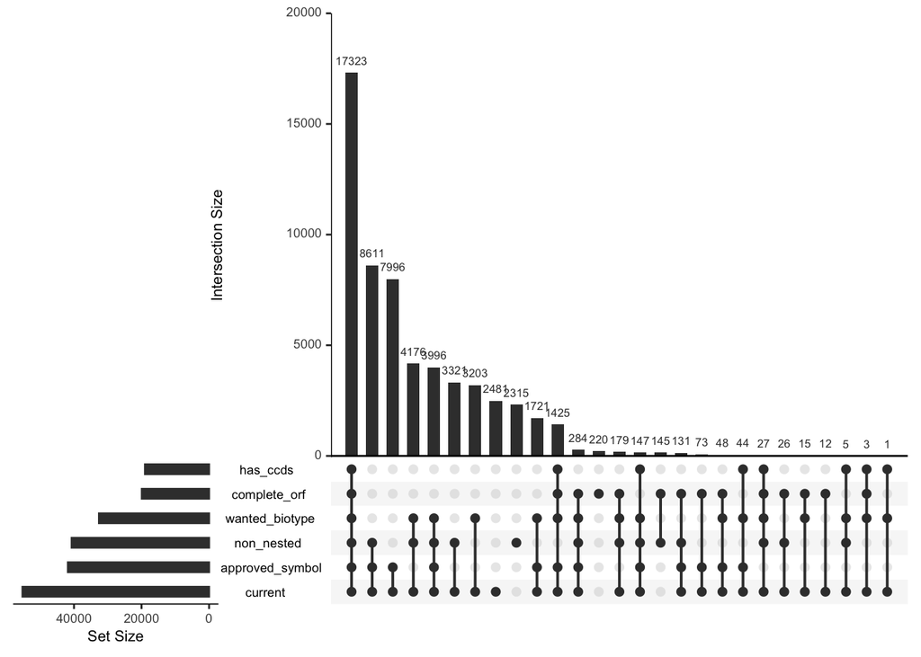

```r
UpSetR::upset(UpSetR::fromList(list(
  current        = gene_tbl$gene_id[gene_tbl$in_ensembl],
  wanted_biotype = gene_tbl$gene_id[gene_tbl$pass_biotype],
  complete_orf   = gene_tbl$gene_id[gene_tbl$complete_orf],
  has_ccds       = gene_tbl$gene_id[gene_tbl$has_ccds],
  approved_symbol = gene_tbl$gene_id[gene_tbl$approved_symbol],
  non_nested     = gene_tbl$gene_id[!gene_tbl$nested_in_full])),
  nsets = 6, order.by = "freq")
```

# 10. Using the table to build the counting annotation

```r
conf <- subset(gene_tbl, keep_high_medium)          # or keep / keep_high / keep_high_no_nested
saf  <- data.frame(GeneID = conf$gene_id, Chr = conf$chr,
                   Start = conf$start, End = conf$end, Strand = conf$strand)
Rsubread::featureCounts(files = <bam>, annot.ext = saf, isGTFAnnotationFile = FALSE,
                        useMetaFeatures = TRUE, strandSpecific = 0, isPairedEnd = TRUE,
                        allowMultiOverlap = FALSE)   # discard ambiguous reads in residual overlaps
```

# 11. Composition of the confident sets

Before the recommendations, here is what each set actually contains. The first table breaks the sets down by biotype; the second puts the summary metrics side by side, with the overlap and nesting burden recomputed within each set (the figure that matters for counting). Tightening from `KEEP` to `KEEP high` shifts the mix toward protein-coding, well-supported genes and pulls the overlap down. `KEEP high (no nested)` is `KEEP high` with the gene-nesting filter applied.

```r
sets <- list(
  `KEEP`                 = gene_tbl$keep,
  `KEEP high`            = gene_tbl$keep_high,
  `KEEP high (no nested)`= gene_tbl$keep_high_no_nested,
  `KEEP high+medium`     = gene_tbl$keep_high_medium
)

# --- biotype composition across the sets ---
bt <- lapply(names(sets), function(s) count(gene_tbl[sets[[s]], ], gene_biotype, name = s))
biotype_tab <- Reduce(function(a, b) full_join(a, b, by = "gene_biotype"), bt) %>%
  mutate(across(-gene_biotype, ~ tidyr::replace_na(.x, 0L))) %>%
  arrange(desc(.data[["KEEP"]]))
kable(biotype_tab, caption = "Biotype composition of each confident set (gene counts)")
```

Biotype composition of each confident set (gene counts)

| gene_biotype | KEEP | KEEP high | KEEP high (no nested) | KEEP high+medium |
| --- | --- | --- | --- | --- |
| protein_coding | 19566 | 18818 | 17467 | 19179 |
| lncRNA | 13031 | 5378 | 3816 | 13031 |

```r
# --- summary metrics across the sets ---
metric_col <- function(mask) {
  d <- gene_tbl[mask, ]; f <- flag_against(gene_tbl, mask)
  c(`n genes`         = format(nrow(d), big.mark = ","),
    `protein_coding`  = sprintf("%.1f%%", 100 * mean(d$gene_biotype == "protein_coding")),
    `lncRNA`          = sprintf("%.1f%%", 100 * mean(d$gene_biotype %in% c("lncRNA","lincRNA"))),
    `has CCDS`        = sprintf("%.1f%%", 100 * mean(d$has_ccds)),
    `complete ORF`    = sprintf("%.1f%%", 100 * mean(d$complete_orf)),
    `multi-exon`      = sprintf("%.1f%%", 100 * mean(d$multi_exon)),
    `approved symbol` = sprintf("%.1f%%", 100 * mean(d$approved_symbol)),
    `TSL <= 1`        = sprintf("%.1f%%", 100 * mean((d$min_tsl <= 1) %in% TRUE)),
    `median width bp` = format(round(median(d$width)), big.mark = ","),
    `overlaps (within set)` = sprintf("%.1f%%", 100 * mean(f$overlaps[mask])),
    `nested (within set)`   = sprintf("%.1f%%", 100 * mean(f$nested[mask])))
}
metrics_tab <- sapply(sets, metric_col)
kable(metrics_tab, caption = "Summary metrics for each confident set")
```

Summary metrics for each confident set

|  | KEEP | KEEP high | KEEP high (no nested) | KEEP high+medium |
| --- | --- | --- | --- | --- |
| n genes | 32,597 | 24,196 | 21,283 | 32,210 |
| protein_coding | 60.0% | 77.8% | 82.1% | 59.5% |
| lncRNA | 40.0% | 22.2% | 17.9% | 40.5% |
| has CCDS | 58.2% | 77.5% | 81.8% | 58.3% |
| complete ORF | 59.2% | 78.2% | 82.4% | 59.9% |
| multi-exon | 90.1% | 95.9% | 96.4% | 90.3% |
| approved symbol | 76.7% | 100.0% | 100.0% | 76.7% |
| TSL <= 1 | 57.3% | 75.2% | 79.3% | 57.7% |
| median width bp | 15,382 | 22,764 | 26,722 | 15,520 |
| overlaps (within set) | 53.7% | 41.8% | 29.2% | 53.2% |
| nested (within set) | 18.9% | 10.5% | 0.0% | 18.8% |

Since nesting is optional, the table below shows how many genes in each set sit nested inside another kept gene, i.e. how many the `_no_nested` variant removes. Nesting is measured against the KEEP set, so `KEEP high (no nested)` is 0% by construction.

```r
nest_row <- function(mask) {
  d <- gene_tbl[mask, ]
  c(`n genes`               = format(sum(mask), big.mark = ","),
    `nested in a kept gene` = sprintf("%d (%.1f%%)", sum(d$nested_in_keep),
                                      100 * mean(d$nested_in_keep)))
}
nest_tab <- sapply(list(
  `KEEP`                  = gene_tbl$keep,
  `KEEP high`             = gene_tbl$keep_high,
  `KEEP high (no nested)` = gene_tbl$keep_high_no_nested,
  `KEEP high+medium`      = gene_tbl$keep_high_medium), nest_row)
kable(nest_tab, caption = "Gene-nesting within each set (nesting measured against the KEEP set)")
```

Gene-nesting within each set (nesting measured against the KEEP set)

|  | KEEP | KEEP high | KEEP high (no nested) | KEEP high+medium |
| --- | --- | --- | --- | --- |
| n genes | 32,597 | 24,196 | 21,283 | 32,210 |
| nested in a kept gene | 6161 (18.9%) | 2913 (12.0%) | 0 (0.0%) | 6103 (18.9%) |

```r
cat(sprintf("Applying the no-nested filter to KEEP high removes %d of %d genes (%.1f%%).\n",
            sum(gene_tbl$keep_high & gene_tbl$nested_in_keep), sum(gene_tbl$keep_high),
            100 * mean(gene_tbl$nested_in_keep[gene_tbl$keep_high])))
```

```
## Applying the no-nested filter to KEEP high removes 2913 of 24196 genes (12.0%).
```

# 12. Recommendations for filtering

This is how we would use the table. There are four filter columns of increasing strictness, each a subset of the one above, so the choice is really how strict to be. (They are set-membership filters; only the last, `keep_high_no_nested`, uses the `nested_in_keep` gene-nesting flag.)

[output not shown]

The sets nest: `keep_high_no_nested` ⊆ `keep_high` ⊆ `keep_high_medium` ⊆ `keep`. Going stricter mainly trades lncRNAs and weakly-supported loci for a cleaner, more coding-focused set with much less overlap (Section 11). `keep` is the floor and drops only retired IDs and off-target biotypes; `keep_high` is what we would trust for the primary analysis; `keep_high_medium` sits between the two when coverage matters more than stringency; `keep_high_no_nested` is `keep_high` with the nested loci gone. We keep nesting as its own step rather than folding it into the tier so it stays the user’s call, since the genes it removes include real nested and bidirectional pairs.

lncRNAs need more caution than coding genes and are a separate decision. Their evidence is thinner (no CCDS, no ORF), the annotation changes faster, and they drive most of the overlap. If the biology needs lncRNAs, include them but lean on the tier: prefer their `high` calls and look at them case by case rather than trusting the whole set.

So: `keep` is the floor, `keep_high` is the default for a coding analysis, `keep_high_medium` trades stringency for coverage, `keep_high_no_nested` adds the nesting filter on top of `keep_high`, and lncRNAs are handled deliberately.